# Multivariate Statistics and Methodology using R

Practical Issues in Structural Equation Modeling

Aja Murray; Aja.Murray@ed.ac.uk

# This week

- Techniques
  - Full structural equation modeling with:
    - Non-normal data
    - Ordered-categorical items
    - Missing data
- Functions
  - sem( ) and cfa( ) from lavaan
- Reading
  - lavaan tutorial: http://lavaan.ugent.be/tutorial/tutorial.pdf (sections 10 and 12)
  - *SEM Practical Issues* on Learn

# Learning outcomes

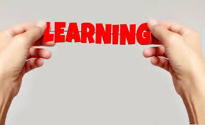

- Know how to deal with non-normal data in SEM
- Know how to fit structural equation models with ordered-categorical items
- Understand the distinction between different missing data mechanisms and how to deal with missingness in SEM

# SEM with continuous normally distributed items

- Thus far we have been assuming that our items approximate continuous distributions
- Justifiable if:
  - We have a truly continuous measure OR
  - We have at least 5 response options AND
  - All 5 response options are used by participants AND
  - The distribution of responses is close to a normal distribution
- If these conditions are met, we can happily use maximum likelihood estimation to fit our models

# Why item distributions matter

- In SEM, non-normality matters because SEM uses the sample covariance matrix
- The sample covariance matrix completely summarises the variation in observed variables only if there is multivariate normality
- If not, information from higher-order moments (skewness, kurtosis) needs to be taken into account

# SEM with continuous non-normally distributed items

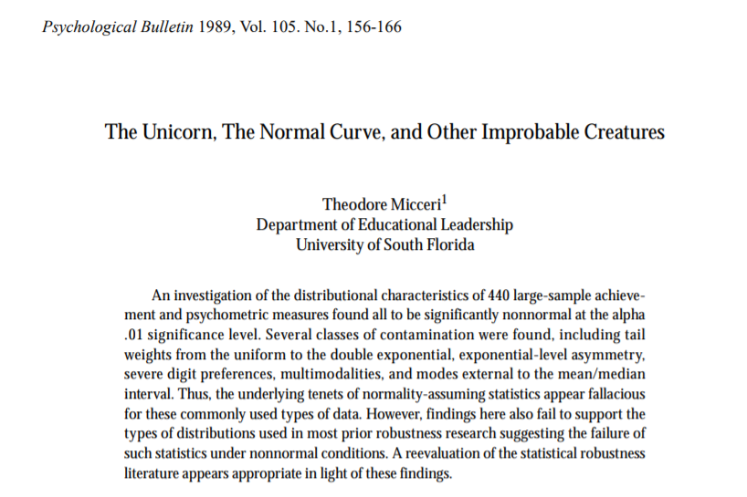

- Continuous but non-normal data is extremely common in psychology

# SEM with continuous non-normally distributed items

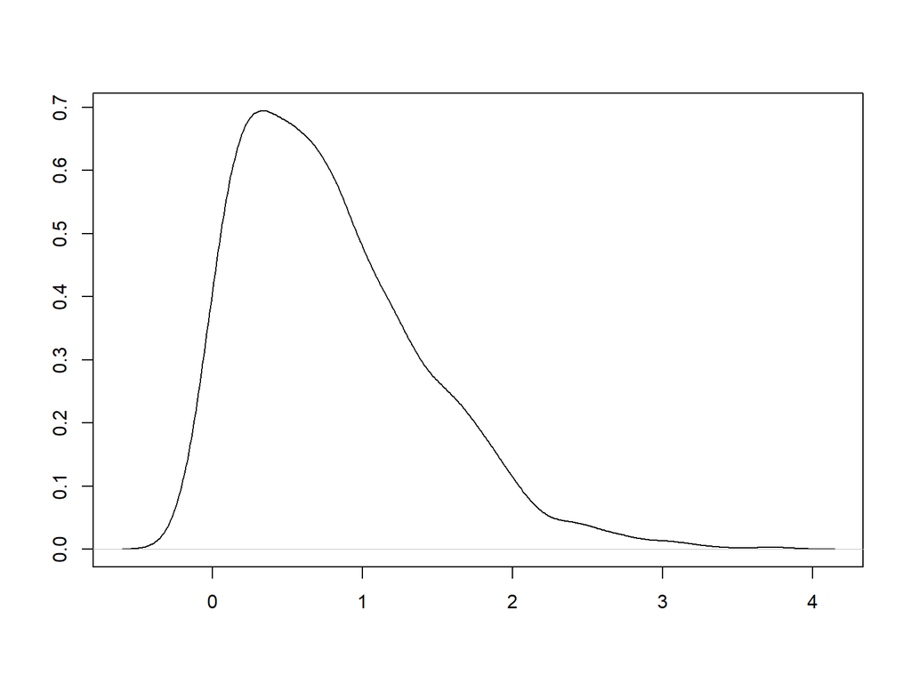

- Consequences of non-normality in SEM are:
  - Model fit is underestimated
  - Standard errors of parameter estimates are under-estimated
  - Statistical significance is overestimated

# Using a robust estimator for non-normally distributed items

- Robust maximum likelihood estimation:
  - Gives the same parameter estimates as ML
  - Corrects the fit statistics using a **correction factor**
  - The correction factor depends on the degree of non-normality
  - More non-normality = a bigger correction
  - Corrects the standard errors using a conceptually similar mechanism

# Example in lavaan

- A researcher wants to test whether a one-factor CFA fits for her 4-item aggression scale
- She collects n=500 datapoints from a set of emerging adults
- The data looks like…

```r
library(psych)
describe(Agg_data)
```

```
##       vars   n mean   sd median trimmed  mad   min  max range skew kurtosis
## item1    1 500 0.01 1.02  -0.40   -0.18 0.59 -0.83 5.32  6.15 1.75     3.30
## item2    2 500 0.05 1.31  -0.42   -0.21 0.83 -1.04 6.34  7.39 1.76     3.13
## item3    3 500 0.17 1.28  -0.24   -0.06 0.96 -0.98 5.25  6.23 1.64     2.63
## item4    4 500 0.11 1.16  -0.37   -0.12 0.64 -0.83 7.26  8.09 2.05     5.57
##         se
## item1 0.05
## item2 0.06
## item3 0.06
## item4 0.05
```

# Observed variable distributions

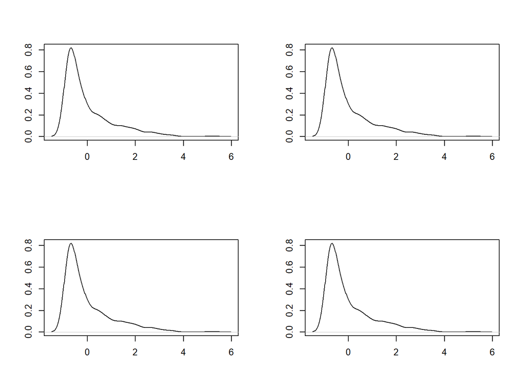

# Fitting the model ignoring non-normality

- First, let’s fit the model ignoring non-normality
- No obvious signs that anything is amiss…
- Important to use descriptive and graphical checks prior to model-fitting

```r
model1<-'Agg=~item1+item2+item3+item4'
model1.est<-cfa(model1, data=Agg_data)
summary(model1.est, fit.measures=T, standardized=T)
```

```
## lavaan 0.6-11 ended normally after 31 iterations
##
##   Estimator                                         ML
##   Optimization method                           NLMINB
##   Number of model parameters                         8
##
##   Number of observations                           500
##
## Model Test User Model:
##
##   Test statistic                                12.998
##   Degrees of freedom                                 2
##   P-value (Chi-square)                           0.002
##
## Model Test Baseline Model:
##
##   Test statistic                               187.030
##   Degrees of freedom                                 6
##   P-value                                        0.000
##
## User Model versus Baseline Model:
##
##   Comparative Fit Index (CFI)                    0.939
##   Tucker-Lewis Index (TLI)                       0.818
##
## Loglikelihood and Information Criteria:
##
##   Loglikelihood user model (H0)              -3097.350
##   Loglikelihood unrestricted model (H1)      -3090.851
##
##   Akaike (AIC)                                6210.700
##   Bayesian (BIC)                              6244.417
##   Sample-size adjusted Bayesian (BIC)         6219.024
##
## Root Mean Square Error of Approximation:
##
##   RMSEA                                          0.105
##   90 Percent confidence interval - lower         0.056
##   90 Percent confidence interval - upper         0.162
##   P-value RMSEA <= 0.05                          0.035
```

[output cut: 11 more lines]

```
## Latent Variables:
##                    Estimate  Std.Err  z-value  P(>|z|)   Std.lv  Std.all
##   Agg =~
##     item1             1.000                               0.583    0.570
##     item2             1.179    0.183    6.439    0.000    0.688    0.524
##     item3             0.942    0.160    5.907    0.000    0.550    0.429
##     item4             1.080    0.167    6.481    0.000    0.630    0.541
##
## Variances:
##                    Estimate  Std.Err  z-value  P(>|z|)   Std.lv  Std.all
##    .item1             0.705    0.068   10.424    0.000    0.705    0.675
##    .item2             1.252    0.108   11.610    0.000    1.252    0.726
##    .item3             1.337    0.100   13.352    0.000    1.337    0.816
##    .item4             0.957    0.086   11.182    0.000    0.957    0.707
##     Agg               0.340    0.070    4.826    0.000    1.000    1.000
```

# Using a robust estimator for non-normal data

- We can use a robust estimator by setting:
  - estimator=‘MLR’ or estimator=‘MLM’
  - each provides a slightly different correction method
  - MLM only works with complete (no missing) data

# Using MLM for non-normal data

```r
model1<-'Agg=~item1+item2+item3+item4'
model1.est<-cfa(model1, data=Agg_data, estimator='MLM')
summary(model1.est, fit.measures=T, standardized=T, ci=T)
```

```
## lavaan 0.6-11 ended normally after 31 iterations
##
##   Estimator                                         ML
##   Optimization method                           NLMINB
##   Number of model parameters                         8
##
##   Number of observations                           500
##
## Model Test User Model:
##                                               Standard      Robust
##   Test Statistic                                12.998       9.941
##   Degrees of freedom                                 2           2
##   P-value (Chi-square)                           0.002       0.007
##   Scaling correction factor                                  1.307
##        Satorra-Bentler correction
##
## Model Test Baseline Model:
##
##   Test statistic                               187.030     114.973
##   Degrees of freedom                                 6           6
##   P-value                                        0.000       0.000
##   Scaling correction factor                                  1.627
##
## User Model versus Baseline Model:
##
##   Comparative Fit Index (CFI)                    0.939       0.927
##   Tucker-Lewis Index (TLI)                       0.818       0.781
##
##   Robust Comparative Fit Index (CFI)                         0.941
##   Robust Tucker-Lewis Index (TLI)                            0.824
##
## Loglikelihood and Information Criteria:
##
##   Loglikelihood user model (H0)              -3097.350   -3097.350
##   Loglikelihood unrestricted model (H1)      -3090.851   -3090.851
##
##   Akaike (AIC)                                6210.700    6210.700
##   Bayesian (BIC)                              6244.417    6244.417
##   Sample-size adjusted Bayesian (BIC)         6219.024    6219.024
##
```

[output cut: 33 more lines]

```
##     0.630    0.541
##
## Variances:
##                    Estimate  Std.Err  z-value  P(>|z|) ci.lower ci.upper
##    .item1             0.705    0.091    7.705    0.000    0.526    0.884
##    .item2             1.252    0.142    8.799    0.000    0.973    1.531
##    .item3             1.337    0.138    9.690    0.000    1.066    1.607
##    .item4             0.957    0.128    7.489    0.000    0.707    1.208
##     Agg               0.340    0.091    3.738    0.000    0.162    0.518
##    Std.lv  Std.all
##     0.705    0.675
##     1.252    0.726
##     1.337    0.816
##     0.957    0.707
##     1.000    1.000
```

# Using MLR for non-normal data

```r
model1<-'Agg=~item1+item2+item3+item4'
model1.est<-cfa(model1, data=Agg_data, estimator='MLR')
summary(model1.est, fit.measures=T, standardized=T, ci=T)
```

```
## lavaan 0.6-11 ended normally after 31 iterations
##
##   Estimator                                         ML
##   Optimization method                           NLMINB
##   Number of model parameters                         8
##
##   Number of observations                           500
##
## Model Test User Model:
##                                                Standard      Robust
##   Test Statistic                                 12.998      13.837
##   Degrees of freedom                                  2           2
##   P-value (Chi-square)                            0.002       0.001
##   Scaling correction factor                                   0.939
##        Yuan-Bentler correction (Mplus variant)
##
## Model Test Baseline Model:
##
##   Test statistic                               187.030     148.841
##   Degrees of freedom                                 6           6
##   P-value                                        0.000       0.000
##   Scaling correction factor                                  1.257
##
## User Model versus Baseline Model:
##
##   Comparative Fit Index (CFI)                    0.939       0.917
##   Tucker-Lewis Index (TLI)                       0.818       0.751
##
##   Robust Comparative Fit Index (CFI)                         0.938
##   Robust Tucker-Lewis Index (TLI)                            0.814
##
## Loglikelihood and Information Criteria:
##
##   Loglikelihood user model (H0)              -3097.350   -3097.350
##   Scaling correction factor                                  2.129
##       for the MLR correction
##   Loglikelihood unrestricted model (H1)      -3090.851   -3090.851
##   Scaling correction factor                                  1.891
##       for the MLR correction
##
```

[output cut: 37 more lines]

```
##     0.630    0.541
##
## Variances:
##                    Estimate  Std.Err  z-value  P(>|z|) ci.lower ci.upper
##    .item1             0.705    0.098    7.201    0.000    0.513    0.897
##    .item2             1.252    0.148    8.434    0.000    0.961    1.543
##    .item3             1.337    0.143    9.341    0.000    1.056    1.617
##    .item4             0.957    0.134    7.148    0.000    0.695    1.220
##     Agg               0.340    0.099    3.433    0.001    0.146    0.534
##    Std.lv  Std.all
##     0.705    0.675
##     1.252    0.726
##     1.337    0.816
##     0.957    0.707
##     1.000    1.000
```

# Summary of what to do when you have non-normal continuous data

- Use MLR to:
  - Obtain corrected model fit statistics
  - Parameter significance tests that are based on corrected standard errors
  - The parameter estimates are the same as from normal ML estimation
- We discussed an example using the cfa() function but this generalises to the sem() function as well

# BREAK 1

- Time for a pause
- Quiz question:
  - Which of these is the best solution for dealing with non-normal data in SEM:
    - 1. log-transform all the variables
    - 2. convert all the variables to z-scores
    - 3. use a correlation matrix rather than a covariance matrix
    - 4. use robust maximum likelihood estimation

# WELCOME BACK 1

- Welcome back!
- The answer to the quiz question is…
- Quiz question:
  - Which of these is the best solution for dealing with non-normal data in SEM:
    - 1. log-transform all the variables
    - 2. convert all the variables to z-scores
    - 3. use a correlation matrix rather than a covariance matrix
    - 4. **use robust maximum likelihood estimation**

# Ordinal-categorical data

- Ordinal-categorical data is also very common in SEM
  - Items usually have a Likert-type scale
  - When there are less than 5 response options that can adversely affect SEM models
- Consequences include:
  - Underestimated correlations between items and associated parameter bias
    - Lower loadings, factor correlations etc.
  - Underestimated model fit

# Solutions for ordinal-categorical data

- Use a **categorical estimator** instead of maximum likelihood estimation
- It is possible to treat ordinal-categorical items ‘as if’ there is a latent continuous variable underlying them
- A series of k-1 thresholds on this continuous distribution is imagined
  - k= number of categories
    - E.g., for a binary item there is one threshold
    - Those below the threshold get a score of 0, those above get a score of 1 for the item
- It is then possible to fit the model based on the assumed associations between the underlying latent continuous variable

# Example: Ordinal data

- Imagine (the more realistic scenario), where our four aggression items are on a binary response scale

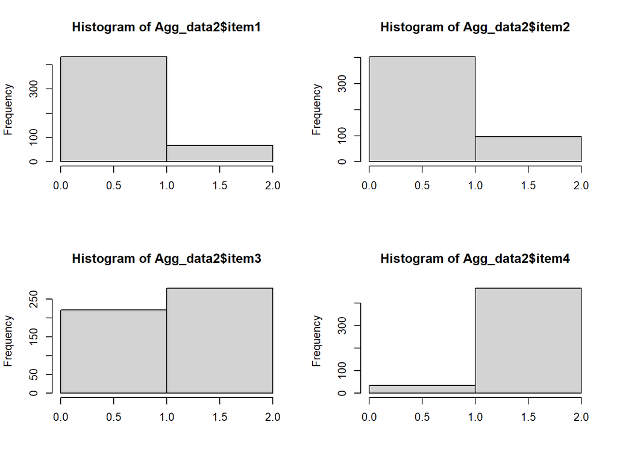

# Fitting a model with ordinal-categorical data

- Let’s first fit the model ignoring the ordinal-categorical nature of the items

```r
model1<-'Agg=~item1+item2+item3+item4'
model1.est<-cfa(model1, data=Agg_data2)
summary(model1.est, fit.measures=T, standardized=T)
```

```
## lavaan 0.6-11 ended normally after 36 iterations
##
##   Estimator                                         ML
##   Optimization method                           NLMINB
##   Number of model parameters                         8
##
##   Number of observations                           500
##
## Model Test User Model:
##
##   Test statistic                                12.856
##   Degrees of freedom                                 2
##   P-value (Chi-square)                           0.002
##
## Model Test Baseline Model:
##
##   Test statistic                                64.410
##   Degrees of freedom                                 6
##   P-value                                        0.000
##
## User Model versus Baseline Model:
##
##   Comparative Fit Index (CFI)                    0.814
##   Tucker-Lewis Index (TLI)                       0.442
##
## Loglikelihood and Information Criteria:
##
##   Loglikelihood user model (H0)               -768.162
##   Loglikelihood unrestricted model (H1)       -761.734
##
##   Akaike (AIC)                                1552.325
##   Bayesian (BIC)                              1586.042
##   Sample-size adjusted Bayesian (BIC)         1560.649
##
## Root Mean Square Error of Approximation:
##
##   RMSEA                                          0.104
##   90 Percent confidence interval - lower         0.055
##   90 Percent confidence interval - upper         0.162
##   P-value RMSEA <= 0.05                          0.036
```

[output cut: 11 more lines]

```
## Latent Variables:
##                    Estimate  Std.Err  z-value  P(>|z|)   Std.lv  Std.all
##   Agg =~
##     item1             1.000                               0.128    0.375
##     item2             1.413    0.440    3.214    0.001    0.180    0.458
##     item3             1.504    0.457    3.287    0.001    0.192    0.387
##     item4             0.527    0.184    2.868    0.004    0.067    0.267
##
## Variances:
##                    Estimate  Std.Err  z-value  P(>|z|)   Std.lv  Std.all
##    .item1             0.100    0.008   11.743    0.000    0.100    0.859
##    .item2             0.123    0.013    9.232    0.000    0.123    0.790
##    .item3             0.210    0.018   11.413    0.000    0.210    0.851
##    .item4             0.059    0.004   13.973    0.000    0.059    0.929
##     Agg               0.016    0.007    2.393    0.017    1.000    1.000
```

# Fitting a model with a categorical estimator

- We can request categorical estimation by setting estimator by letting lavaan know which items are categorical
- We do this using the ‘ordered’ argument in the cfa() function

```r
model1<-'Agg=~item1+item2+item3+item4'
model1.est<-cfa(model1, data=Agg_data2, ordered=c('item1','item2','item3','item4'))
summary(model1.est, fit.measures=T, standardized=T)
```

```
## lavaan 0.6-11 ended normally after 24 iterations
##
##   Estimator                                       DWLS
##   Optimization method                           NLMINB
##   Number of model parameters                         8
##
##   Number of observations                           500
##
## Model Test User Model:
##                                               Standard      Robust
##   Test Statistic                                 7.257       7.807
##   Degrees of freedom                                 2           2
##   P-value (Chi-square)                           0.027       0.020
##   Scaling correction factor                                  0.943
##   Shift parameter                                            0.115
##        simple second-order correction
##
## Model Test Baseline Model:
##
##   Test statistic                                80.264      75.274
##   Degrees of freedom                                 6           6
##   P-value                                        0.000       0.000
##   Scaling correction factor                                  1.072
##
## User Model versus Baseline Model:
##
##   Comparative Fit Index (CFI)                    0.929       0.916
##   Tucker-Lewis Index (TLI)                       0.788       0.749
##
##   Robust Comparative Fit Index (CFI)                            NA
##   Robust Tucker-Lewis Index (TLI)                               NA
##
## Root Mean Square Error of Approximation:
##
##   RMSEA                                          0.073       0.076
##   90 Percent confidence interval - lower         0.021       0.026
##   90 Percent confidence interval - upper         0.133       0.136
##   P-value RMSEA <= 0.05                          0.194       0.166
##
##   Robust RMSEA                                                  NA
```

[output cut: 35 more lines]

```
##
## Variances:
##                    Estimate  Std.Err  z-value  P(>|z|)   Std.lv  Std.all
##    .item1             0.733                               0.733    0.733
##    .item2             0.669                               0.669    0.669
##    .item3             0.676                               0.676    0.676
##    .item4             0.550                               0.550    0.550
##     Agg               0.267    0.106    2.526    0.012    1.000    1.000
##
## Scales y*:
##                    Estimate  Std.Err  z-value  P(>|z|)   Std.lv  Std.all
##     item1             1.000                               1.000    1.000
##     item2             1.000                               1.000    1.000
##     item3             1.000                               1.000    1.000
##     item4             1.000                               1.000    1.000
```

# Summary of what to do with ordered-categorical items

- Declare your items as ‘ordered’ and use a categorical estimator
- This gives you parameter estimates/fit statistics ‘as if’ analysing the associations between underlying continous variables

# BREAK 2

- Time for a pause
- Quiz question:
  - Using a categorical estimator, how many thresholds would an item with 3 response options have:
    - 1. 1
    - 2. 2
    - 3. 3
    - 4. 4

# Welcome back 2

- Welcome back!
- The answer to the quiz question is…
  - Using a categorical estimator, how many thresholds would an item with 3 response options have:
    - 1. 1
    - 2. **2**
    - 3. 3
    - 4. 4

# Missing data

- Missing data is a near-universal feature of real data
- It reduces our sample size
  - Less precision and statistical power
- If missingness is ‘non-random’ it can also bias our parameter estimates

# Missing data mechanisms

- Rubin defined three different possible missing data mechanisms:
  - **Missing completely at random (MCAR)**
  - **Missing at random (MAR)**
  - **Missing not at random (MNAR)**
- The effects of missingness depend on a combination of the missing data mechanism and the method we use to deal with it

# MAR

- Missing at random (MAR) means:
  - When the probability of missing data on a variable Y is related to other variables in the model but not to the values of Y itself
- Example:
  - X = self-control and Y= aggression.
  - People with lower self-control are more likely to have missing data on aggression
  - After taking into account self-control, people who are high in aggression are no more likely to have missing data on aggression
  - Challenge is that there is no way to confirm that there is no relation between aggression scores and missing data on aggression because that would knowledge of the missing scores
- Common misconception is that Little’s test can be used to confirm MAR

# MCAR

- Genuinely random missingness
- No relation between Y or any other variable in the model and missingness on Y
- The data you have are a simple random sample of the complete data
- The ideal missing data scenario!
- Example:
  - X = self-control and Y= aggression
  - People of all levels of self-control and aggression are equally likely to have missing data on aggression

# MNAR

- Missing not random (MNAR) means:
- When the probability of missingness on Y is related to the values of Y itself
- Example:
  - X= self-control, Y= aggression
  - Those high in aggression are more likely to have missing data on the aggression variable, even after taking into account self-control
- As with MAR, there is no way to verify that data are MNAR without knowledge of the missing values

# Methods of dealing with missingness

- Deletion methods:
  - Listwise deletion
  - Pairwise deletion
- Imputation methods:
  - Mean imputation
  - Regression imputation
  - Multiple imputation
- Maximum likelihood estimation
- Methods for MNAR data:
  - Pattern mixture models
  - Random coefficient models

# Listwise deletion

- ‘complete case analysis’
- Example:
  - Delete everyone from the analysis who has missing data on either self-control or aggression
- Will give biased results unless data are MCAR
- Even if data are MCAR, power will be reduced by reducing the sample size
- Bottom line: **not recommended**

# Pairwise deletion

- ‘available-case analysis’
- Uses available data for each analysis
- Different cases contribute to different correlations in a correlation matrix
- Example:
  - Cases 2,3,7,18, 56, 100 not used in the self-control- aggression correlation
  - Cases 2,7,18,77, 103 not used in the aggression-substance use correlation
- Doesn’t reduce power as much as listwise deletion
- But still gives biased results whenever data are not MCAR
- Bottom line: **not recommended**

# Mean imputation

- Replace missing values with the mean on that variable
- Example:
  - Replace missing aggression values with the mean of the aggression variable
- Two major issues:
  - artificially reduces the variability of the data
  - can give very biased estimates even when data are MCAR
- Bottom line: **not recommended**
- ‘possibly the worst missing data handling method available… you should absolutely avoid this approach’ Enders (2011)

# Regression imputation

- Replaces the missing values with values predicted from a regression
- Estimate a set of regression equations where the incomplete variables are predicted from the complete variables
- Use the regression equations to calculate the predicted values on the incomplete variables
- Based on the principle of using information from the complete data to estimate the missing data
- Two forms:
  - ‘normal’ regression imputation
  - Stochastic regression imputation (adds a residual term to overcome loss of variance)
- Stochastic regression is preferred and gives unbiased results if data are MAR

# Multiple imputation

- Procedure:
  - Imputes missing data several times to create multiple complete datasets
  - Can include many more predictor variables in imputation model than analysis model
  - Analyses are conducted for each dataset
  - Analysis results are pooled across datasets to get parameter estimates and standard errors
  - 3-5 datasets are often enough but more is better and 20+ is ideal
- Unlike in most single imputation approaches, the standard errors take account of the additional uncertainty due to missingness
- Gives unbiased parameter estimates under MAR
- Can be cumbersome if pooling has to be done by hand but usually pooling can be automated
- Bottom line: **recommended** method if data are likely to be MAR

# Full Information Maximum Likelihood (FIML) Estimation method

- Makes use of all the information in the model to arrive at the parameter estimates ‘as if’ the data were complete
- Does not ‘impute’ individual values
- Gives unbiased estimates under MAR
- Even under MCAR it is superior to listwise and pairwise deletion because it uses more information from the observed data
- Practical advantage= easy to implement, usually much more so than multiple imputation
- Bottom line: **recommended** method if data are likely to be MAR

# Missingness in lavaan

- The default method of dealing with missingness in lavaan is listwise deletion
- If data are continuous we can easily switch to one of the recommended methods: FIML

```r
model1<-'Agg=~item1+item2+item3+item4'
model1.est<-cfa(model1, data=Agg_data, missing='ML')
summary(model1.est, fit.measures=T, standardized=T)
```

```
## lavaan 0.6-11 ended normally after 31 iterations
##
##   Estimator                                         ML
##   Optimization method                           NLMINB
##   Number of model parameters                        12
##
##   Number of observations                           500
##   Number of missing patterns                         1
##
## Model Test User Model:
##
##   Test statistic                                12.998
##   Degrees of freedom                                 2
##   P-value (Chi-square)                           0.002
##
## Model Test Baseline Model:
##
##   Test statistic                               187.030
##   Degrees of freedom                                 6
##   P-value                                        0.000
##
## User Model versus Baseline Model:
##
##   Comparative Fit Index (CFI)                    0.939
##   Tucker-Lewis Index (TLI)                       0.818
##
## Loglikelihood and Information Criteria:
##
##   Loglikelihood user model (H0)              -3097.350
##   Loglikelihood unrestricted model (H1)      -3090.851
##
##   Akaike (AIC)                                6218.700
##   Bayesian (BIC)                              6269.275
##   Sample-size adjusted Bayesian (BIC)         6231.186
##
## Root Mean Square Error of Approximation:
##
##   RMSEA                                          0.105
##   90 Percent confidence interval - lower         0.056
##   90 Percent confidence interval - upper         0.162
```

[output cut: 20 more lines]

```
## Intercepts:
##                    Estimate  Std.Err  z-value  P(>|z|)   Std.lv  Std.all
##    .item1             0.011    0.046    0.245    0.807    0.011    0.011
##    .item2             0.050    0.059    0.851    0.395    0.050    0.038
##    .item3             0.172    0.057    3.004    0.003    0.172    0.134
##    .item4             0.105    0.052    2.024    0.043    0.105    0.091
##     Agg               0.000                               0.000    0.000
##
## Variances:
##                    Estimate  Std.Err  z-value  P(>|z|)   Std.lv  Std.all
##    .item1             0.705    0.070   10.127    0.000    0.705    0.675
##    .item2             1.252    0.110   11.346    0.000    1.252    0.726
##    .item3             1.337    0.103   13.001    0.000    1.337    0.816
##    .item4             0.957    0.090   10.656    0.000    0.957    0.707
##     Agg               0.340    0.072    4.699    0.000    1.000    1.000
```

# Advanced topics in missingness

- Missingness with ordered-categorical data:
  - Unfortunately the FIML option is not available with ordered-categorical data
  - Instead we must use multiple imputation
    - mice package + lavaan.survey package
    - mice can create the imputed datasets for us
    - lavaan.survey can be used to pool them
- MNAR data:
- If we suspect that the data are not MAR or MCAR there are other options available
  - Random coefficient models
  - Selection models
- However, these methods are based on strong, untestable assumptions
- If these assumptions are false, can result in even greater bias
- Many, therefore, argue that multiple imputation or MAR are best even if MNAR is suspected

# Summary of missingess

- The lavaan default is listwise deletion but this is a suboptimal method
  - Biased parameter estimates unless data are MCAR
  - Inefficient even if data are MCAR
- FIML can be easily used with continuous data
- Multiple imputation (not covered in this course) is needed for categorical data